# *Merged Jupyter Notebook*

# from file: Reference_Notebook_Milestone_1_Time_Series

# **Milestone 1**

## **Context**

Global warming is one of the foremost problems that humanity needs to solve to ensure our survival for the future. There is enough scientific evidence to suggest that there could be catastrophic effects if we donâ€™t start controlling the amount of damage we do to our environment and ecosystem.

One of the primary contributors to global warming is the accumulation of greenhouse gases in our atmosphere. These greenhouse gases are generated as a result of various industrial and economic activities that we conduct in our day-to-day lives and CO2 is one of the biggest contributors to this greenhouse effect. The need of the hour is to be able to identify the sources of CO2 and see how to assess the impact and potential ways to control the emission.

A lot of electricity in the US is still generated by various sources of energy that are burned to run turbines to generate electricity, and the burning of these fuels is the primary source of CO2 emissions. Different approaches and technological advancements are being used to minimize the emission of carbon & trade-off between carbon emission and affordable electricity production for mankind. Forecasting CO2 emissions can make an impact on decision-making in terms of emission reduction & choosing better methods of electricity production.

## **Objective**

-Forecast the carbon emissions value for natural gas (NNEIEUS) fuel type for the next 12 months and propose certain measures that can be adopted as policies to reduce these emissions.

## **Key questions**

Forecasting CO2 intensity and related CO2 emissions is important today and will become urgent in the future to recommend effective CO2 emissions reduction policies to the policymakers.

## **Problem Formulation**:

- The problem on hand is forecast Carbon Emission based on a dataset that includes CO2 emissions from 9 different energy resource between January 1973 to July 2016.

## **Attributes Information:**

This datset is the past monthly data of Carbon dioxide emissions from electricity generation from the US Energy Information Administration categorized by fuel type such as Coal, Natural gas etc.

**MSN:-** Reference to Mnemonic Series Names (U.S. Energy Information Administration Nomenclature)

**YYYYMM:-** The month of the year on which these emissions were observed

**Value:-** Amount of CO2 Emissions in Million Metric Tons of Carbon Dioxide

**Description:-** Different category of electricity production through which carbon is emissioned.

## **Important Notes**

- This notebook can be considered a guide to refer to while solving the problem. The evaluation will be as per the Rubric shared for each Milestone. Unlike previous courses, it does not follow the pattern of the graded questions in different sections. This notebook would give you a direction on what steps need to be taken in order to get a viable solution to the problem. Please note that this is just one way of doing this. There can be other 'creative' ways to solve the problem and we urge you to feel free and explore them as an 'optional' exercise.
- In the notebook, there are markdown cells called - Observations and Insights. It is a good practice to provide observations and extract insights from the outputs.
- The naming convention for different variables can vary. Please consider the code provided in this notebook as a sample code.
- All the outputs in the notebook are just for reference and can be different if you follow a different approach.
- There are sections called **Think About It** in the notebook that will help you get a better understanding of the reasoning behind a particular technique/step. Interested learners can take alternative approaches if they want to explore different techniques.

### **Loading the libraries**

```python
# Uncomment to upgrade statsmodels
!pip install statsmodels --upgrade --user
```

```python
#Import basic libraries
import pandas as pd
import warnings
import itertools
import numpy as np
import statsmodels.api as sm
import matplotlib.pyplot as plt
import matplotlib.pylab
```

### **Loading the data**

```python
df = pd.read_excel('MER_T12_06.xlsx')
df.head()
```

|  | MSN | YYYYMM | Value | Description |
| --- | --- | --- | --- | --- |
| 0 | CLEIEUS | 197301 | 72.076 | Coal Electric Power Sector CO2 Emissions |
| 1 | CLEIEUS | 197302 | 64.442 | Coal Electric Power Sector CO2 Emissions |
| 2 | CLEIEUS | 197303 | 64.084 | Coal Electric Power Sector CO2 Emissions |
| 3 | CLEIEUS | 197304 | 60.842 | Coal Electric Power Sector CO2 Emissions |
| 4 | CLEIEUS | 197305 | 61.798 | Coal Electric Power Sector CO2 Emissions |

```python
#to ignore warnings
import warnings
import itertools
warnings.filterwarnings("ignore")
```

```python
#conversion of "YYYYMM" columnn into standard datetime format & making it as index
# We are using errors=â€™coerceâ€™. It will replace all non-numeric values with NaN.

dateparse = lambda x: pd.to_datetime(x, format='%Y%m', errors = 'coerce')
df = pd.read_excel('MER_T12_06.xlsx', parse_dates=['YYYYMM'], index_col='YYYYMM', date_parser=dateparse)
df.head(15)
```

| YYYYMM | MSN | Value | Description |
| --- | --- | --- | --- |
| 1973-01-01 | CLEIEUS | 72.076 | Coal Electric Power Sector CO2 Emissions |
| 1973-02-01 | CLEIEUS | 64.442 | Coal Electric Power Sector CO2 Emissions |
| 1973-03-01 | CLEIEUS | 64.084 | Coal Electric Power Sector CO2 Emissions |
| 1973-04-01 | CLEIEUS | 60.842 | Coal Electric Power Sector CO2 Emissions |
| 1973-05-01 | CLEIEUS | 61.798 | Coal Electric Power Sector CO2 Emissions |
| 1973-06-01 | CLEIEUS | 66.538 | Coal Electric Power Sector CO2 Emissions |
| 1973-07-01 | CLEIEUS | 72.626 | Coal Electric Power Sector CO2 Emissions |
| 1973-08-01 | CLEIEUS | 75.181 | Coal Electric Power Sector CO2 Emissions |
| 1973-09-01 | CLEIEUS | 68.397 | Coal Electric Power Sector CO2 Emissions |
| 1973-10-01 | CLEIEUS | 67.668 | Coal Electric Power Sector CO2 Emissions |
| 1973-11-01 | CLEIEUS | 67.021 | Coal Electric Power Sector CO2 Emissions |
| 1973-12-01 | CLEIEUS | 71.118 | Coal Electric Power Sector CO2 Emissions |
| NaT | CLEIEUS | 811.791 | Coal Electric Power Sector CO2 Emissions |
| 1974-01-01 | CLEIEUS | 70.55 | Coal Electric Power Sector CO2 Emissions |
| 1974-02-01 | CLEIEUS | 62.929 | Coal Electric Power Sector CO2 Emissions |

**The arguments can be explained as:**

- **parse_dates:** This is a key to identify the date time column. Example, the column name is ‘YYYYMM’.
- **index_col:** This is a key that forces pandas to use the date time column as index.
- **date_parser:** Converts an input string into datetime variable.
- Let us first identify and **drop the non datetimeindex** rows. First, let's convert the index to datetime, coerce errors, and filter NaT

```python
ts = df[pd.Series(pd.to_datetime(df.index, errors='coerce')).notnull().values]
ts.head()
```

| YYYYMM | MSN | Value | Description |
| --- | --- | --- | --- |
| 1973-01-01 | CLEIEUS | 72.076 | Coal Electric Power Sector CO2 Emissions |
| 1973-02-01 | CLEIEUS | 64.442 | Coal Electric Power Sector CO2 Emissions |
| 1973-03-01 | CLEIEUS | 64.084 | Coal Electric Power Sector CO2 Emissions |
| 1973-04-01 | CLEIEUS | 60.842 | Coal Electric Power Sector CO2 Emissions |
| 1973-05-01 | CLEIEUS | 61.798 | Coal Electric Power Sector CO2 Emissions |

```python
#Check the datatypes of each column. Hint: Use dtypes method
ts.dtypes
```

```
MSN            object
Value          object
Description    object
dtype: object
```

```python
#convert the emision value into numeric value
ts["Value"] = pd.to_numeric(ts["Value"],errors='coerce')
ts.info()
ts.head()
```

```
<class 'pandas.core.frame.DataFrame'>
DatetimeIndex: 4707 entries, 1973-01-01 to 2016-07-01
Data columns (total 3 columns):
 #   Column       Non-Null Count  Dtype
---  ------       --------------  -----
 0   MSN          4707 non-null   object
 1   Value        4323 non-null   float64
 2   Description  4707 non-null   object
dtypes: float64(1), object(2)
memory usage: 147.1+ KB
```

| YYYYMM | MSN | Value | Description |
| --- | --- | --- | --- |
| 1973-01-01 | CLEIEUS | 72.076 | Coal Electric Power Sector CO2 Emissions |
| 1973-02-01 | CLEIEUS | 64.442 | Coal Electric Power Sector CO2 Emissions |
| 1973-03-01 | CLEIEUS | 64.084 | Coal Electric Power Sector CO2 Emissions |
| 1973-04-01 | CLEIEUS | 60.842 | Coal Electric Power Sector CO2 Emissions |
| 1973-05-01 | CLEIEUS | 61.798 | Coal Electric Power Sector CO2 Emissions |

```python
#Check total number of missing values of each column. Hint: Use isnull() method
ts.isnull().sum()
```

```
MSN              0
Value          384
Description      0
dtype: int64
```

```python
#Drop the missing value using dropna(inplace = True)
ts.dropna(inplace = True)
```

### **Dataset visualization**

```python
energy_sources = ts.groupby('Description')
energy_sources.head()
```

| YYYYMM | MSN | Value | Description |
| --- | --- | --- | --- |
| 1973-01-01 | CLEIEUS | 72.076 | Coal Electric Power Sector CO2 Emissions |
| 1973-02-01 | CLEIEUS | 64.442 | Coal Electric Power Sector CO2 Emissions |
| 1973-03-01 | CLEIEUS | 64.084 | Coal Electric Power Sector CO2 Emissions |
| 1973-04-01 | CLEIEUS | 60.842 | Coal Electric Power Sector CO2 Emissions |
| 1973-05-01 | CLEIEUS | 61.798 | Coal Electric Power Sector CO2 Emissions |
| 1973-01-01 | NNEIEUS | 12.175 | Natural Gas Electric Power Sector CO2 Emissions |
| 1973-02-01 | NNEIEUS | 11.708 | Natural Gas Electric Power Sector CO2 Emissions |
| 1973-03-01 | NNEIEUS | 13.994 | Natural Gas Electric Power Sector CO2 Emissions |
| 1973-04-01 | NNEIEUS | 14.627 | Natural Gas Electric Power Sector CO2 Emissions |
| 1973-05-01 | NNEIEUS | 17.344 | Natural Gas Electric Power Sector CO2 Emissions |
| 1973-01-01 | DKEIEUS | 2.375 | Distillate Fuel, Including Kerosene-Type Jet F... |
| 1973-02-01 | DKEIEUS | 2.061 | Distillate Fuel, Including Kerosene-Type Jet F... |
| 1973-03-01 | DKEIEUS | 1.171 | Distillate Fuel, Including Kerosene-Type Jet F... |
| 1973-04-01 | DKEIEUS | 1.022 | Distillate Fuel, Including Kerosene-Type Jet F... |
| 1973-05-01 | DKEIEUS | 0.949 | Distillate Fuel, Including Kerosene-Type Jet F... |
| 1973-01-01 | PCEIEUS | 0.128 | Petroleum Coke Electric Power Sector CO2 Emiss... |
| 1973-02-01 | PCEIEUS | 0.106 | Petroleum Coke Electric Power Sector CO2 Emiss... |
| 1973-03-01 | PCEIEUS | 0.083 | Petroleum Coke Electric Power Sector CO2 Emiss... |
| 1973-04-01 | PCEIEUS | 0.130 | Petroleum Coke Electric Power Sector CO2 Emiss... |
| 1973-05-01 | PCEIEUS | 0.167 | Petroleum Coke Electric Power Sector CO2 Emiss... |
| 1973-01-01 | RFEIEUS | 24.867 | Residual Fuel Oil Electric Power Sector CO2 Em... |
| 1973-02-01 | RFEIEUS | 20.867 | Residual Fuel Oil Electric Power Sector CO2 Em... |
| 1973-03-01 | RFEIEUS | 19.780 | Residual Fuel Oil Electric Power Sector CO2 Em... |
| 1973-04-01 | RFEIEUS | 16.562 | Residual Fuel Oil Electric Power Sector CO2 Em... |
| 1973-05-01 | RFEIEUS | 17.754 | Residual Fuel Oil Electric Power Sector CO2 Em... |
| 1973-01-01 | PAEIEUS | 27.369 | Petroleum Electric Power Sector CO2 Emissions |
| 1973-02-01 | PAEIEUS | 23.034 | Petroleum Electric Power Sector CO2 Emissions |
| 1973-03-01 | PAEIEUS | 21.034 | Petroleum Electric Power Sector CO2 Emissions |
| 1973-04-01 | PAEIEUS | 17.714 | Petroleum Electric Power Sector CO2 Emissions |
| 1973-05-01 | PAEIEUS | 18.870 | Petroleum Electric Power Sector CO2 Emissions |
| 1989-01-01 | GEEIEUS | 0.031 | Geothermal Energy Electric Power Sector CO2 Em... |
| 1989-02-01 | GEEIEUS | 0.028 | Geothermal Energy Electric Power Sector CO2 Em... |
| 1989-03-01 | GEEIEUS | 0.031 | Geothermal Energy Electric Power Sector CO2 Em... |
| 1989-04-01 | GEEIEUS | 0.030 | Geothermal Energy Electric Power Sector CO2 Em... |
| 1989-05-01 | GEEIEUS | 0.031 | Geothermal Energy Electric Power Sector CO2 Em... |
| 1989-01-01 | NWEIEUS | 0.371 | Non-Biomass Waste Electric Power Sector CO2 Em... |
| 1989-02-01 | NWEIEUS | 0.335 | Non-Biomass Waste Electric Power Sector CO2 Em... |
| 1989-03-01 | NWEIEUS | 0.371 | Non-Biomass Waste Electric Power Sector CO2 Em... |
| 1989-04-01 | NWEIEUS | 0.359 | Non-Biomass Waste Electric Power Sector CO2 Em... |
| 1989-05-01 | NWEIEUS | 0.371 | Non-Biomass Waste Electric Power Sector CO2 Em... |
| 1973-01-01 | TXEIEUS | 111.621 | Total Energy Electric Power Sector CO2 Emissions |
| 1973-02-01 | TXEIEUS | 99.185 | Total Energy Electric Power Sector CO2 Emissions |
| 1973-03-01 | TXEIEUS | 99.112 | Total Energy Electric Power Sector CO2 Emissions |
| 1973-04-01 | TXEIEUS | 93.183 | Total Energy Electric Power Sector CO2 Emissions |
| 1973-05-01 | TXEIEUS | 98.012 | Total Energy Electric Power Sector CO2 Emissions |

#### **Visualize the dependency of the emission in the power generation with time.**

```python
cols = ['Geothermal Energy', 'Non-Biomass Waste', 'Petroleum Coke','Distillate Fuel ',
        'Residual Fuel Oil', 'Petroleum', 'Natural Gas', 'Coal', 'Total Emissions']
```

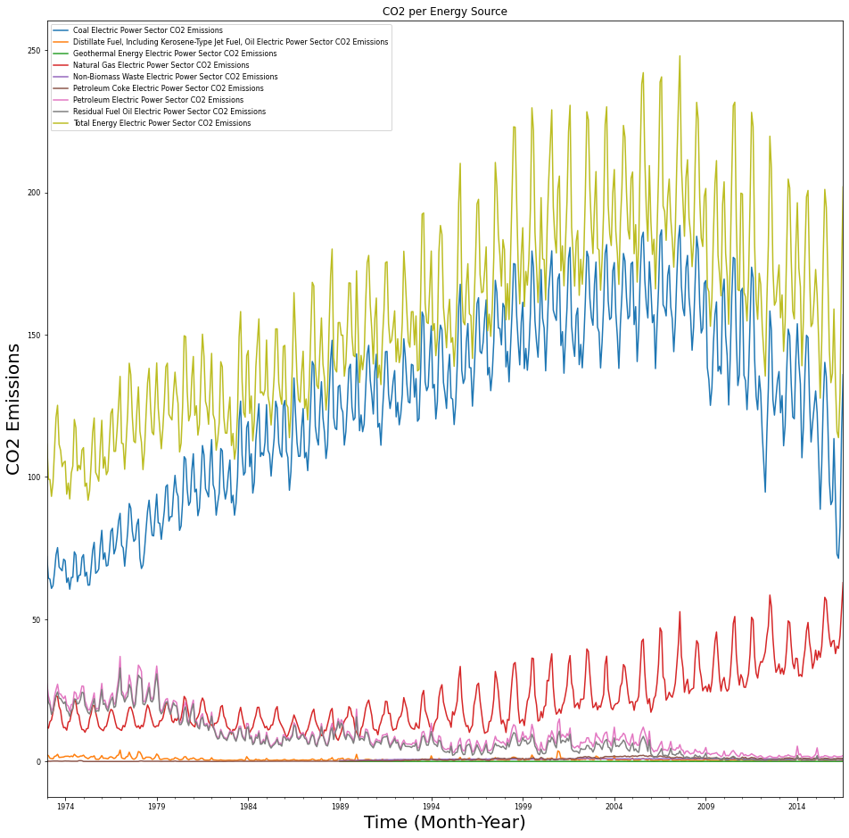

```python
fig, ax = plt.subplots(figsize=(16,16))
for desc, group  in energy_sources:
    group.plot(y='Value', label=desc,ax = ax, title='CO2 per Energy Source', fontsize = 8)
    ax.set_xlabel('Time (Month-Year)')
    ax.set_ylabel('CO2 Emissions')
    ax.xaxis.label.set_size(20)
    ax.yaxis.label.set_size(20)
    ax.legend(fontsize = 8)
```

#### **Visualize the trend of CO2 emission from each energy source individually**

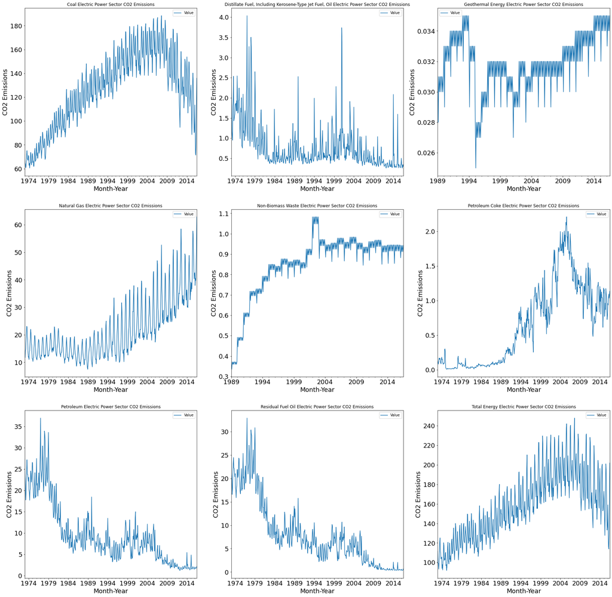

```python
###Code here
fig, axes = plt.subplots(3,3, figsize = (30, 30))
for (desc, group), ax in zip(energy_sources, axes.flatten()):
    group.plot( y='Value',ax = ax, title=desc, fontsize = 18)
    ax.set_xlabel('Month-Year')
    ax.set_ylabel('CO2 Emissions')
    ax.xaxis.label.set_size(18)
    ax.yaxis.label.set_size(18)
```

#### **Observations and Insights: **__****

- The individual plots shows both Petroleum and Residual Fuel Oil gradually declining since 1975 which indicates less usage of both energy source
- Natural Gas continues to show increase in total COs produces which indicates increase in usuage
- Coal shows the most CO2 produce of all energy source with it’s peak around 2008 – 2009 and a downward trend since then which indicates less usage and possible better control measures
- Geotherman energy source shows the least amount of CO2 procudes, almost at 0.

#### **Bar chart of CO2 Emissions per energy source**

```python
CO2_per_source = ts.groupby('Description')['Value'].sum().sort_values()
CO2_per_source.index
```

```
Index(['Geothermal Energy Electric Power Sector CO2 Emissions',
       'Non-Biomass Waste Electric Power Sector CO2 Emissions',
       'Petroleum Coke Electric Power Sector CO2 Emissions',
       'Distillate Fuel, Including Kerosene-Type Jet Fuel, Oil Electric Power Sector CO2 Emissions',
       'Residual Fuel Oil Electric Power Sector CO2 Emissions',
       'Petroleum Electric Power Sector CO2 Emissions',
       'Natural Gas Electric Power Sector CO2 Emissions',
       'Coal Electric Power Sector CO2 Emissions',
       'Total Energy Electric Power Sector CO2 Emissions'],
      dtype='object', name='Description')
```

```python
cols = ['Geothermal Energy', 'Non-Biomass Waste', 'Petroleum Coke','Distillate Fuel ',
        'Residual Fuel Oil', 'Petroleum', 'Natural Gas', 'Coal', 'Total Emissions']
```

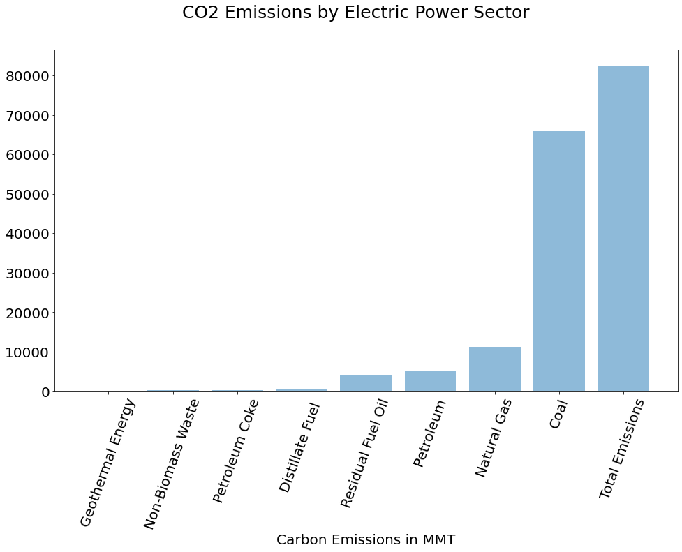

```python
fig = plt.figure(figsize = (16,9))
x_label = cols
x_tick = np.arange(len(cols))
plt.bar(x_tick, CO2_per_source, align = 'center', alpha = 0.5)
fig.suptitle("CO2 Emissions by Electric Power Sector", fontsize= 25)
plt.xticks(x_tick, x_label, rotation = 70, fontsize = 20)
plt.yticks(fontsize = 20)
plt.xlabel('Carbon Emissions in MMT', fontsize = 20)
plt.show()
```

#### **For developing the time series model and forcasting, use the natural gas CO2 emission from the electirical power generation**

```python
emiss = ts.iloc[:,1:]   # Monthly total emissions (mte)
print(emiss)
emiss = emiss.groupby(['Description', pd.Grouper(freq="M")])['Value'].sum().unstack(level = 0)
mte = emiss['Natural Gas Electric Power Sector CO2 Emissions'] # monthly total emissions (mte)
mte.head()
```

```
              Value                                       Description
YYYYMM
1973-01-01   72.076          Coal Electric Power Sector CO2 Emissions
1973-02-01   64.442          Coal Electric Power Sector CO2 Emissions
1973-03-01   64.084          Coal Electric Power Sector CO2 Emissions
1973-04-01   60.842          Coal Electric Power Sector CO2 Emissions
1973-05-01   61.798          Coal Electric Power Sector CO2 Emissions
...             ...                                               ...
2016-03-01  115.997  Total Energy Electric Power Sector CO2 Emissions
2016-04-01  113.815  Total Energy Electric Power Sector CO2 Emissions
2016-05-01  129.440  Total Energy Electric Power Sector CO2 Emissions
2016-06-01  172.074  Total Energy Electric Power Sector CO2 Emissions
2016-07-01  201.958  Total Energy Electric Power Sector CO2 Emissions

[4323 rows x 2 columns]
```

```
YYYYMM
1973-01-31    12.175
1973-02-28    11.708
1973-03-31    13.994
1973-04-30    14.627
1973-05-31    17.344
Freq: M, Name: Natural Gas Electric Power Sector CO2 Emissions, dtype: float64
```

#### **Observations & insights: **_****

- There are a total of 9 different energy source in the data
- The data covers timeframe between January 1973 through July 2016
- Over the years Geothermal Energy sources produces the least amount of CO2

## **Proposed approach**

- **Potential techniques -** What different techniques should be explored?
  - Autoregressive Integrated Moving Average (ARIMA)
- **Overall solution design -** What is the potential solution design?
  - Find optimal parameters to build seasonal Autoregressive Integrated Moving Average (SARIMA) model using grid search method.
  - Diagnosing time series prediction
  - Validating the predictive power.
  - Forecasting 10 year future CO2 emission from power generation using natural gas.
- **Measures of success -** What are the key measures of success?

# from file: Reference_Notebook_Milestone_2_Time_Series

# **Milestone 2**

### **Natural gas based CO2 emission forecasting**

For developing the time series model and forecasting, you are expected to use the natural gas CO2 emission from the electrical power generation. We need to slice this data:

```python
###Slice the data to get the monthly total CO2 emissions of Natural Gas Electric Power Sector
emiss = ts.iloc[:,1:]   # Monthly total emissions (mte)
emiss = emiss.groupby(['Description', pd.Grouper(freq="M")])['Value'].agg('sum')
#emiss = emiss.reset_index()
#print(emiss)
mte = emiss['Natural Gas Electric Power Sector CO2 Emissions'] # monthly total emissions (mte)
mte.head()
```

```
YYYYMM
1973-01-31    12.175
1973-02-28    11.708
1973-03-31    13.994
1973-04-30    14.627
1973-05-31    17.344
Freq: M, Name: Value, dtype: float64
```

```python
 #Check 1st few rows of data
print(mte)
```

```
YYYYMM
1973-01-31    12.175
1973-02-28    11.708
1973-03-31    13.994
1973-04-30    14.627
1973-05-31    17.344
               ...
2016-03-31    40.525
2016-04-30    39.763
2016-05-31    44.210
2016-06-30    53.567
2016-07-31    62.881
Freq: M, Name: Value, Length: 523, dtype: float64
```

### **Split the dataset**

```python
# Split the data into train and test
df_train = mte.loc['1973-01-01':'2015-07-31'].to_frame(name='Value')
df_test = mte.loc['2015-08-31':'2016-07-31'].to_frame(name='Value')
print(df_train)
print(df_test)
```

```
             Value
YYYYMM
1973-01-31  12.175
1973-02-28  11.708
1973-03-31  13.994
1973-04-30  14.627
1973-05-31  17.344
...            ...
2015-03-31  38.872
2015-04-30  36.610
2015-05-31  40.440
2015-06-30  48.920
2015-07-31  57.712

[511 rows x 1 columns]
             Value
YYYYMM
2015-08-31  56.662
2015-09-30  49.384
2015-10-31  43.680
2015-11-30  40.394
2015-12-31  42.270
2016-01-31  42.566
2016-02-29  37.918
2016-03-31  40.525
2016-04-30  39.763
2016-05-31  44.210
2016-06-30  53.567
2016-07-31  62.881
```

### **Test the Stationarity**

```python
#Import the required package

import statsmodels
import statsmodels.api as sm
from statsmodels.tsa.stattools import coint, adfuller
matplotlib.rcParams['figure.figsize'] = [20, 16]
```

### **Test the stationarity through Visualization**

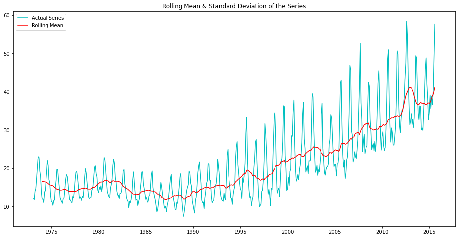

```python
# Calculate the rolling mean and standard deviation for a window of 12 observations
rolmean=df_train.rolling(window=12).mean()
rolstd=df_train.rolling(window=12).std()

# Visualize the rolling mean and standard deviation
plt.figure(figsize=(16,8))
actual = plt.plot(df_train, color='c', label='Actual Series')
rollingmean = plt.plot(rolmean, color='red', label='Rolling Mean')
#rollingstd = plt.plot(rolstd, color='green', label='Rolling Std. Dev.')
plt.title('Rolling Mean & Standard Deviation of the Series')
plt.legend()
plt.show()
```

#### **Observations and Insights: *__***

- We can see there is an upward trend in the series.
- We can confirm that **the series is not stationary.**

### **Test the stationarity using the Augmented Dickey-Fuller Test**

Use the **Augmented Dickey-Fuller (ADF) Test** to verify if the series is stationary or not. The null and alternate hypotheses for the ADF Test are defined as:

**- Null hypothesis:** The Time Series is non-stationary

**- Alternative hypothesis:** The Time Series is stationary

```python
#Define a function to use adfuller test

def get_adfuller(dataset):
  #Importing adfuller using statsmodels
  from statsmodels.tsa.stattools import adfuller
  print('Dickey-Fuller Test: ')
  adftest = adfuller(dataset['Value'])
  adfoutput = pd.Series(adftest[0:4], index=['Test Statistic','p-value','Lags Used','No. of Observations'])
  for key,value in adftest[4].items():
    adfoutput['Critical Value (%s)'%key] = value
  print(adfoutput)
get_adfuller(df_train)
```

```
Dickey-Fuller Test:
Test Statistic            1.459996
p-value                   0.997370
Lags Used                19.000000
No. of Observations     491.000000
Critical Value (1%)      -3.443739
Critical Value (5%)      -2.867444
Critical Value (10%)     -2.569915
dtype: float64
```

- **Observations and Insights**
- The p-value ~ 0.99 i.e. > 0.05 (For 95% confidence intervals) therefore, we fail to reject the null hypothesis.
- We can confirm that the series is non-stationary.

### **Transformation of the dataset into a stationary one**

**We can use some of the following methods to convert a non-stationary series into a stationary one:**

1. Log Transformation
2. Differencing the series (lagged series)

We take the average of ‘k’ consecutive values depending on the frequency of time series (in this capstone 12 months).

Here, we will take the average over the past 1 year.

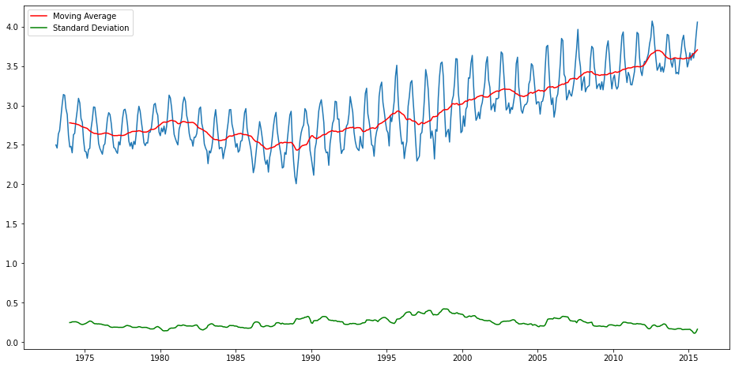

```python
 # Visualize the rolling mean and standard deviation after using log transformation
plt.figure(figsize=(16,8))
df_log = np.log(df_train.astype('float'))
MAvg = df_log.rolling(window=12).mean()
MStd = df_log.rolling(window=12).std()
plt.plot(df_log)
plt.plot(MAvg, color='r', label = 'Moving Average')
plt.plot(MStd, color='g', label = 'Standard Deviation')
plt.legend()
plt.show()
```

**Observations and Insights: **_****

- The series is still showing an updward trend which indicates that it is still no-stationary
- Standard deviation is almost constant ~ 0.25

**Visualize the rolling mean and rolling standard deviation of the shifted series (df_shift) and check the stationarity by calling the adfuller() function. Also, write your observations on the same.**

#### **Think about it:**

- Do you need to remove the null values that we get after applying differencing method?

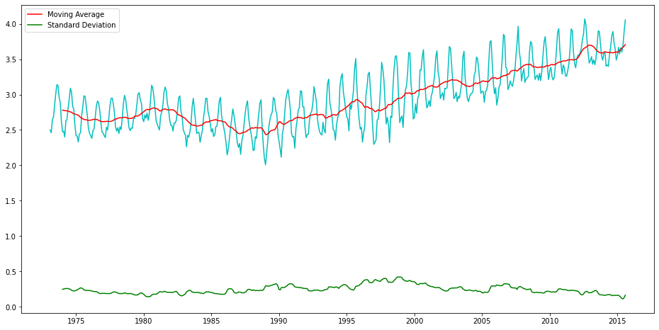

```python
##Code here
plt.figure(figsize=(16,8))
df_shift = df_log - df_log.shift(periods = 1)
MAvg_shift = df_log.rolling(window=12).mean()
MStd_shift = df_log.rolling(window=12).std()
plt.plot(df_log, color='c')
plt.plot(MAvg, color='red', label = 'Moving Average')
plt.plot(MStd, color='green', label = 'Standard Deviation')
plt.legend()
plt.show()

#Dropping the null values that we get after applying differencing method
df_shift = df_shift.dropna()
```

**Observations and Insights: **_****

```python
get_adfuller(df_shift)
```

```
Dickey-Fuller Test:
Test Statistic           -4.865670
p-value                   0.000041
Lags Used                18.000000
No. of Observations     491.000000
Critical Value (1%)      -3.443739
Critical Value (5%)      -2.867444
Critical Value (10%)     -2.569915
dtype: float64
```

**Observations and Insights: **_****

### **Elimination of trend and seasonality: Decomposition**

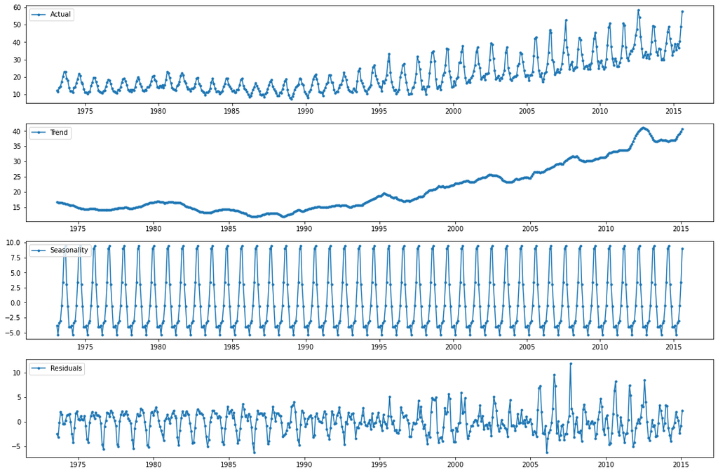

```python
#Importing the seasonal_decompose function to decompose the time series

# You can follow the previous case study/projects notebook to plot it
from statsmodels.tsa.seasonal import seasonal_decompose
decomp = seasonal_decompose(df_train)

trend = decomp.trend
seasonal = decomp.seasonal
residual = decomp.resid

plt.figure(figsize=(15,10))
plt.subplot(411)
plt.plot(df_train, label='Actual', marker='.')
plt.legend(loc='upper left')
plt.subplot(412)
plt.plot(trend, label='Trend', marker='.')
plt.legend(loc='upper left')
plt.subplot(413)
plt.plot(seasonal, label='Seasonality', marker='.')
plt.legend(loc='upper left')
plt.subplot(414)
plt.plot(residual, label='Residuals', marker='.')
plt.legend(loc='upper left')
plt.tight_layout()
```

**Observations and Insights: *__***

- Here we can see that the trend, seasonality are separated out from data and we can model the residuals.

**Plot the auto-correlation function and partial auto-correlation function to get p and q values for AR, MA, ARMA, and ARIMA models**

### **Find optimal parameters (P, Q) and build the AR, MA, ARMA & ARIMA models**

**Plot the ACF and PACF charts and find the optimal parameters**

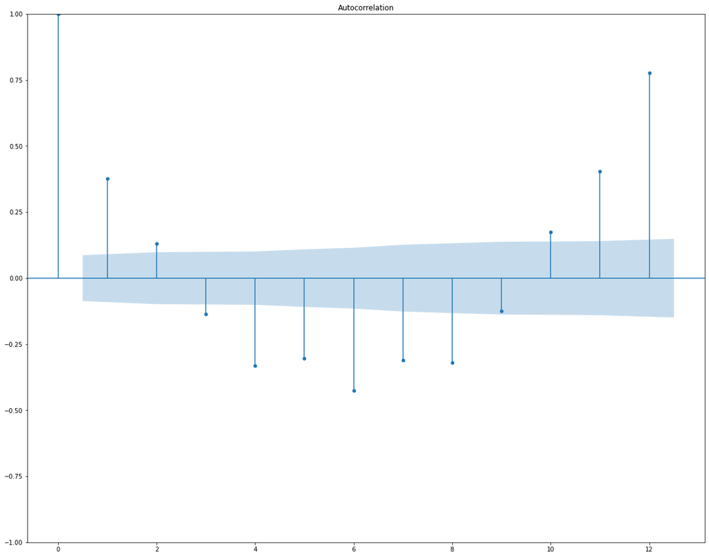

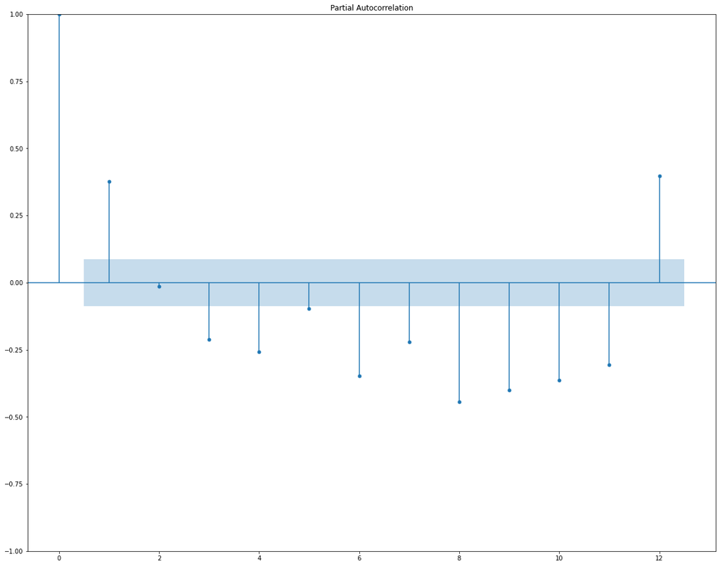

```python
from statsmodels.graphics.tsaplots import plot_acf,plot_pacf

plt.figure(figsize = (8,4))
plot_acf(df_shift, lags = 12)
plt.show()
plot_pacf(df_shift, lags = 12)
plt.show()
```

**Observations and Insights: **_****

- From the above PACF plot we can see that the highest lag at which the plot extends beyond the statistically significant boundary is lag 12.
- This indicates that an AR Model of lag 12 (p=12) should be sufficient to fit the data.
- Similarly, from the ACF plot, we can infer that q=12.

### **AR Model**

Order p is the lag value after which the PACF plot crosses the upper confidence interval for the first time. These p lags will act as our features while forecasting the AR time series.

Fit and predict the shifted series with the AR Model and calculate the RMSE. Also, visualize the time series and write your observations.

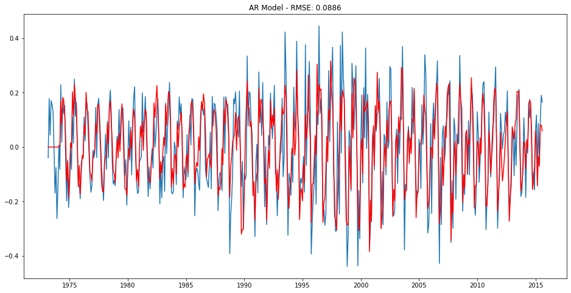

```python
#To calculate the MSE or RMSE
from sklearn.metrics import mean_squared_error
#Importing AutoReg function to apply AR model
from statsmodels.tsa.ar_model import AutoReg

plt.figure(figsize=(16,8))
model_AR = AutoReg(df_shift,lags=12) #Use number of lags as 12 from ACF Plot
results_AR = model_AR.fit() #fit the model
plt.plot(df_shift)
predict = results_AR.predict(start=0,end=len(df_shift)-1) #predict the series
predict = predict.fillna(0) #Converting NaN values to 0
plt.plot(predict, color='red')
plt.title('AR Model - RMSE: %.4f'% mean_squared_error(predict,df_shift['Value'], squared=False))  #Calculating rmse
plt.show()
```

**Observations & Insights: **_****

- we get root mean squared error (RMSE) ~ 0.08

### **MA Model**

#### **Think about it:**

- Do we really have to find AR & I value other than 0 to forecast on the MA based model?

Order q of the MA process is obtained from the ACF plot, this is the lag after which ACF crosses the upper confidence interval for the first time.

Fit and predict the shifted series with the MA Model and calculate the RMSE. Also, visualize the time series and write your observations.

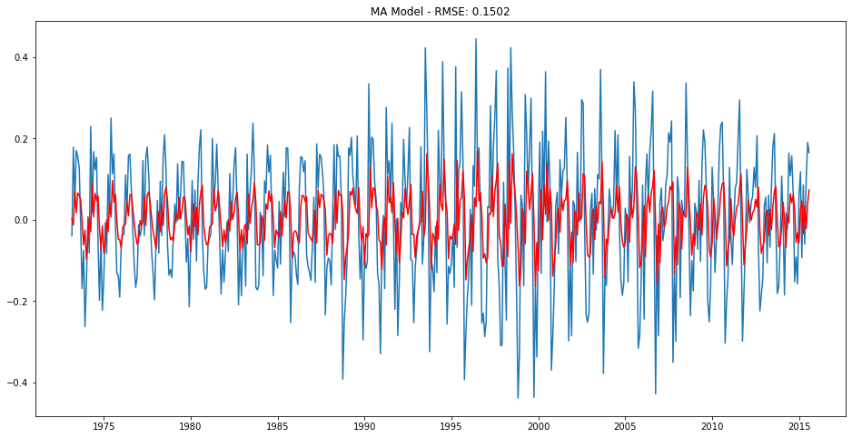

```python
from  statsmodels.tsa.arima.model import ARIMA

plt.figure(figsize=(16,8))
model_MA = ARIMA(df_shift, order=(1, 0, 1)) #Using p=12, d=0, q=12 and apply ARIMA function on df_shift series
results_MA = model_MA.fit() #fit the model
plt.plot(df_shift)
plt.plot(results_MA.fittedvalues, color='red')
plt.title('MA Model - RMSE: %.4f'% mean_squared_error(results_MA.fittedvalues,df_shift['Value'], squared=False))
plt.show()
```

**Observations & Insights: **_****

### **ARMA MODEL**

Fit and predict the shifted series with the ARMA Model and calculate the RMSE. Also, visualize the time series and write your observations.

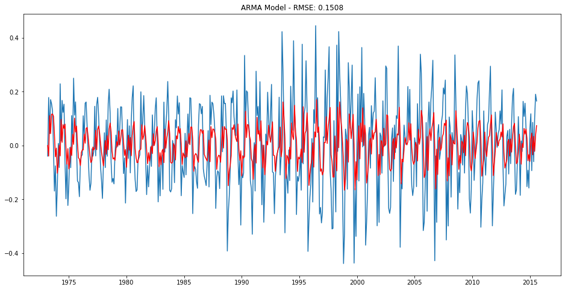

```python
#Code here
plt.figure(figsize=(16,8))
model_ARMA = ARIMA(df_shift, order=(1,1, 1)) #Using p=12, d=0, q=12 and apply ARIMA function on df_shift series
results_ARMA = model_ARMA.fit()
plt.plot(df_shift)
plt.plot(results_ARMA.fittedvalues, color='red')
plt.title('ARMA Model - RMSE: %.4f'% mean_squared_error(results_ARMA.fittedvalues,df_shift['Value'], squared=False))
plt.show()
```

**Observations & Insights: **_****

- The ARMA model is giving the same RMSE as MA model.
- The AR model has the lowest RMSE of all 3.

**Check the AIC value of the model**

```python
#Code here
results_ARMA.aic
```

```
-473.0507543296007
```

### **ARIMA MODEL**

**Fit and predict the shifted series with the ARIMA Model and calculate the RMSE. Also, visualize the time series and write your observations.**

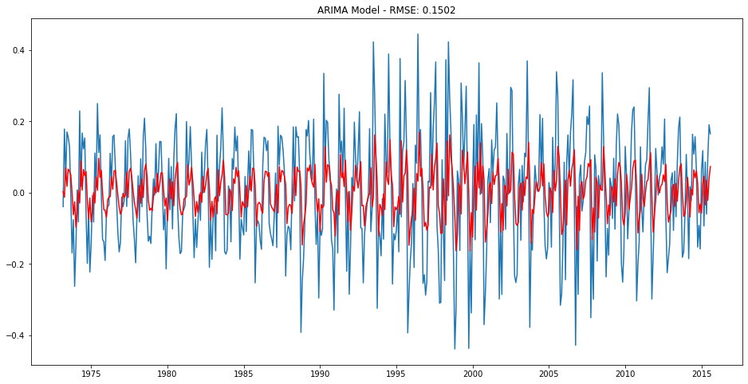

```python
#Code here
from statsmodels.tsa.arima.model import ARIMA
plt.figure(figsize=(16,8))
model_ARIMA = ARIMA(df_shift, order=(1,0,1))  #Using p=0, d=0, q=1 and apply ARIMA function on df_log series
results_ARIMA = model_ARIMA.fit()
#results_ARIMA.fittedvalues = results_ARIMA.fittedvalues[0:498]
plt.plot(df_shift)
plt.plot(results_ARIMA.fittedvalues, color='red')
plt.title('ARIMA Model - RMSE: %.4f'% mean_squared_error(results_ARIMA.fittedvalues,df_shift['Value'], squared=False))
plt.show()
```

```python
# Printing the fitted values from arima
predictions=pd.Series(results_ARIMA.fittedvalues)
predictions
```

```
YYYYMM
1973-02-28    0.003179
1973-03-31   -0.012733
1973-04-30    0.069751
1973-05-31    0.017640
1973-06-30    0.066237
                ...
2015-03-31   -0.034034
2015-04-30    0.035144
2015-05-31   -0.021239
2015-06-30    0.040038
2015-07-31    0.073440
Freq: M, Length: 510, dtype: float64
```

### **Inverse Transformation**

**Use the correct inverse transformation depending on the model chosen to get back the original values.**

**Apply an inverse transformation on the predictions of the chosen model**

```python
#Add the code blocks based on the requirements
predictions_cumsum = predictions.cumsum() # use .cumsum fuction on the predictions


predictions_log = pd.Series(df_log['Value'].iloc[0], index=df_log.index)
predictions_log = predictions_log.add(predictions_cumsum, fill_value=0)
#predictions_log
#df_log['Value'].iloc[0]
predictions_ARIMA = np.exp(predictions_log) #use exponential function
predictions_ARIMA
```

```
YYYYMM
1973-01-31    12.175000
1973-02-28    12.213768
1973-03-31    12.059237
1973-04-30    12.930415
1973-05-31    13.160535
                ...
2015-03-31    49.893880
2015-04-30    51.678526
2015-05-31    50.592481
2015-06-30    52.659196
2015-07-31    56.672031
Freq: M, Length: 511, dtype: float64
```

**Plot the original vs predicted series**

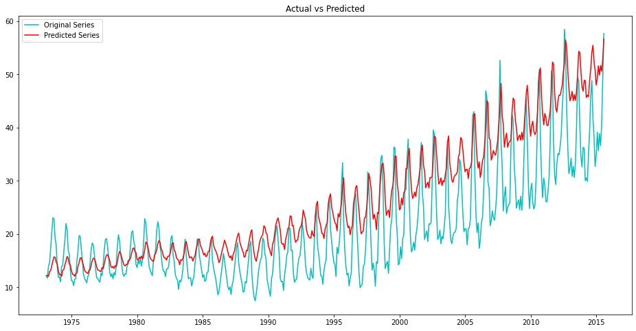

```python
#Code here
plt.figure(figsize=(16,8))
plt.plot(df_train, color = 'c', label = 'Original Series')  #plot the original train series
plt.plot(predictions_ARIMA, color = 'r', label = 'Predicted Series')  #plot the predictions ARIMA
plt.title('Actual vs Predicted')
plt.legend()
plt.show()
```

**Observations & Insights: **_****

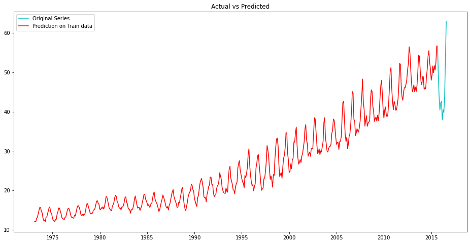

| YYYYMM | Value |
| --- | --- |
| 1973-01-31 | 12.175 |
| 1973-02-28 | 11.708 |
| 1973-03-31 | 13.994 |
| 1973-04-30 | 14.627 |
| 1973-05-31 | 17.344 |
| ... | ... |
| 2015-03-31 | 38.872 |
| 2015-04-30 | 36.610 |
| 2015-05-31 | 40.440 |
| 2015-06-30 | 48.920 |
| 2015-07-31 | 57.712 |

511 rows × 1 columns

```python
#Add the code blocks based on the requirements
forecasted_ARIMA = results_ARIMA.forecast(steps=24)  #forecast using the results_ARIMA for next 24 months. Keep steps=24
#forecasted_ARIMA
forecasted_cumsum = forecasted_ARIMA.cumsum()
#forecasted_cumsum
index = pd.date_range('2016-01-1','2018-1-1' , freq='1M')- pd.offsets.MonthBegin(1)
df1 = pd.DataFrame()
df1['cumsum'] = forecasted_cumsum
df1.index = index
df1
df1['Forecasted'] = df1['cumsum']
#df1['Forecasted']
forecasted_ARIMA = np.exp(df_log)
plt.figure(figsize=(16,8))
plt.plot(df_test, color = 'c', label = 'Original Series')
plt.plot(predictions_ARIMA, color = 'r', label = 'Prediction on Train data') #plot the predictions ARIMA series
#plt.plot(forecasted_ARIMA, label = 'Prediction on Test data', color='b')  #plot the forecasted ARIMA series
plt.title('Actual vs Predicted')
plt.legend()
plt.show()
forecasted_ARIMA
```

```python
p = d = q = range(0, 2) # Define the p, d and q parameters to take any value between 0 and 2
pdq = list(itertools.product(p, d, q)) # Generate all different combinations of p, q and q triplets
pdq_x_QDQs = [(x[0], x[1], x[2], 12) for x in list(itertools.product(p, d, q))] # Generate all different combinations of seasonal p, q and q triplets
print('Examples of Seasonal ARIMA parameter combinations for Seasonal ARIMA...')
print('SARIMAX: {} x {}'.format(pdq[1], pdq_x_QDQs[1]))
print('SARIMAX: {} x {}'.format(pdq[2], pdq_x_QDQs[2]))
```

```
Examples of Seasonal ARIMA parameter combinations for Seasonal ARIMA...
SARIMAX: (0, 0, 1) x (0, 0, 1, 12)
SARIMAX: (0, 1, 0) x (0, 1, 0, 12)
```

```python
print(pdq)
print(pdq_x_QDQs)
```

```
[(0, 0, 0), (0, 0, 1), (0, 1, 0), (0, 1, 1), (1, 0, 0), (1, 0, 1), (1, 1, 0), (1, 1, 1)]
[(0, 0, 0, 12), (0, 0, 1, 12), (0, 1, 0, 12), (0, 1, 1, 12), (1, 0, 0, 12), (1, 0, 1, 12), (1, 1, 0, 12), (1, 1, 1, 12)]
```

#### **Think about it:**

- Can we use other than RMSE measurement to check the performance of the model?

```python
for param in pdq:
    for seasonal_param in pdq_x_QDQs:
        try:
            mod = sm.tsa.statespace.SARIMAX(mte,
                                            order=param,
                                            seasonal_order=seasonal_param,
                                            enforce_stationarity=False,
                                            enforce_invertibility=False)
            results = mod.fit()
            print('ARIMA{}x{} - AIC:{}'.format(param, param_seasonal, results.aic))
        except:
            continue

a=[]
b=[]
c=[]
wf=pd.DataFrame()
```

[output not shown]

```python
mod = sm.tsa.statespace.SARIMAX(mte,
                                order=(1,1,1),
                                seasonal_order=(0,1,1,12),
                                enforce_stationarity=False,
                                enforce_invertibility=False)
results = mod.fit()
print(results.summary())
```

```
                                     SARIMAX Results
==========================================================================================
Dep. Variable:                              Value   No. Observations:                  523
Model:             SARIMAX(1, 1, 1)x(0, 1, 1, 12)   Log Likelihood                -997.777
Date:                            Fri, 05 Nov 2021   AIC                           2003.553
Time:                                    12:57:03   BIC                           2020.380
Sample:                                01-31-1973   HQIC                          2010.158
                                     - 07-31-2016
Covariance Type:                              opg
==============================================================================
                 coef    std err          z      P>|z|      [0.025      0.975]
------------------------------------------------------------------------------
ar.L1          0.6684      0.040     16.560      0.000       0.589       0.748
ma.L1         -0.9534      0.020    -46.799      0.000      -0.993      -0.914
ma.S.L12      -0.7287      0.027    -27.036      0.000      -0.782      -0.676
sigma2         3.2378      0.133     24.263      0.000       2.976       3.499
===================================================================================
Ljung-Box (L1) (Q):                   0.23   Jarque-Bera (JB):               183.59
Prob(Q):                              0.63   Prob(JB):                         0.00
Heteroskedasticity (H):               7.58   Skew:                             0.43
Prob(H) (two-sided):                  0.00   Kurtosis:                         5.85
===================================================================================

Warnings:
[1] Covariance matrix calculated using the outer product of gradients (complex-step).
```

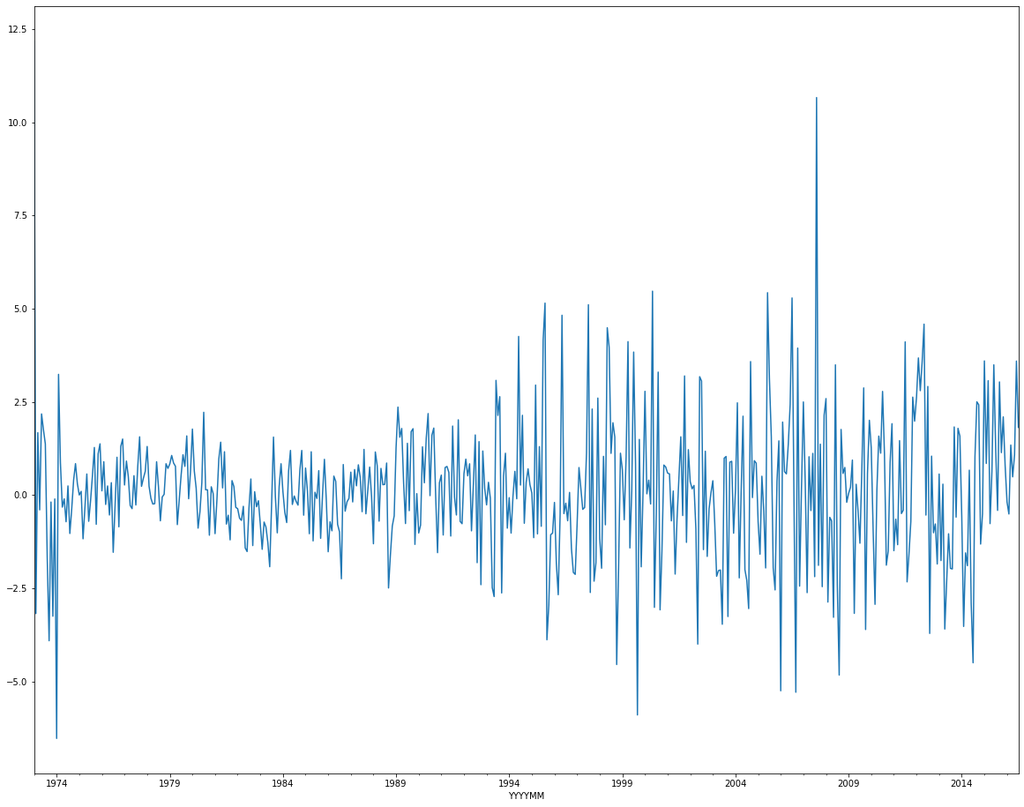

```python
results.resid.plot()
```

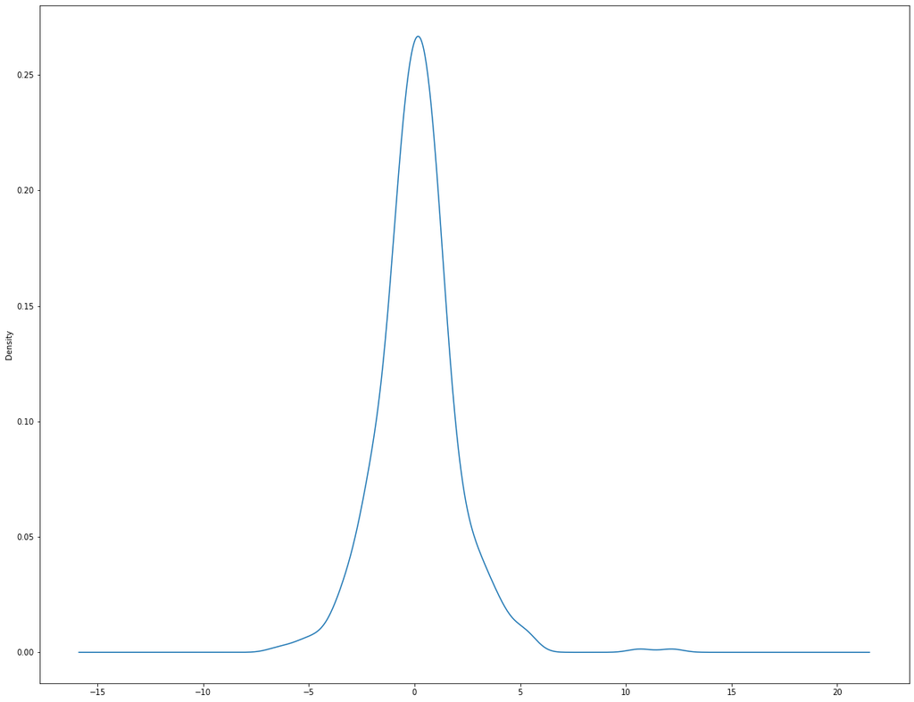

```python
results.resid.plot(kind='kde')
```

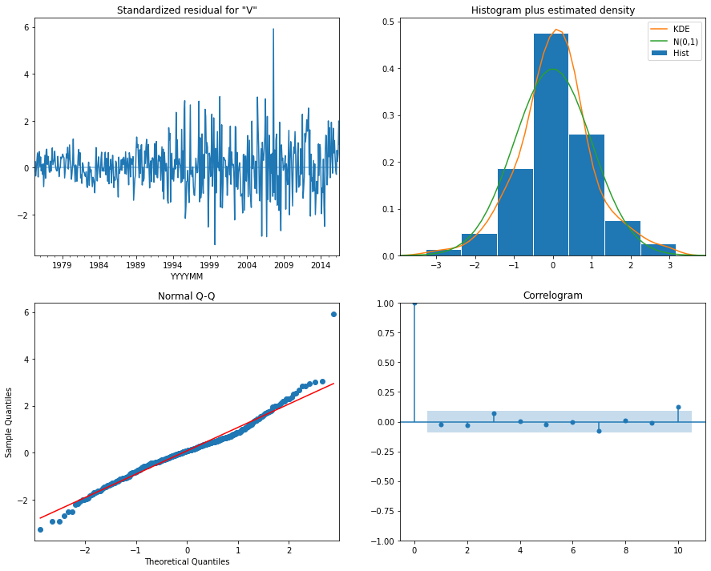

```python
results.plot_diagnostics(figsize=(15, 12))
plt.show()
```

```python
pred = results.get_prediction(start = 480, end = 523, dynamic=False)
pred_ci = pred.conf_int()
pred_ci.head()
```

|  | lower Value | upper Value |
| --- | --- | --- |
| 2013-01-31 | 30.203834 | 37.257324 |
| 2013-02-28 | 29.088380 | 36.141870 |
| 2013-03-31 | 28.958984 | 36.012474 |
| 2013-04-30 | 30.708073 | 37.761563 |
| 2013-05-31 | 32.104079 | 39.157569 |

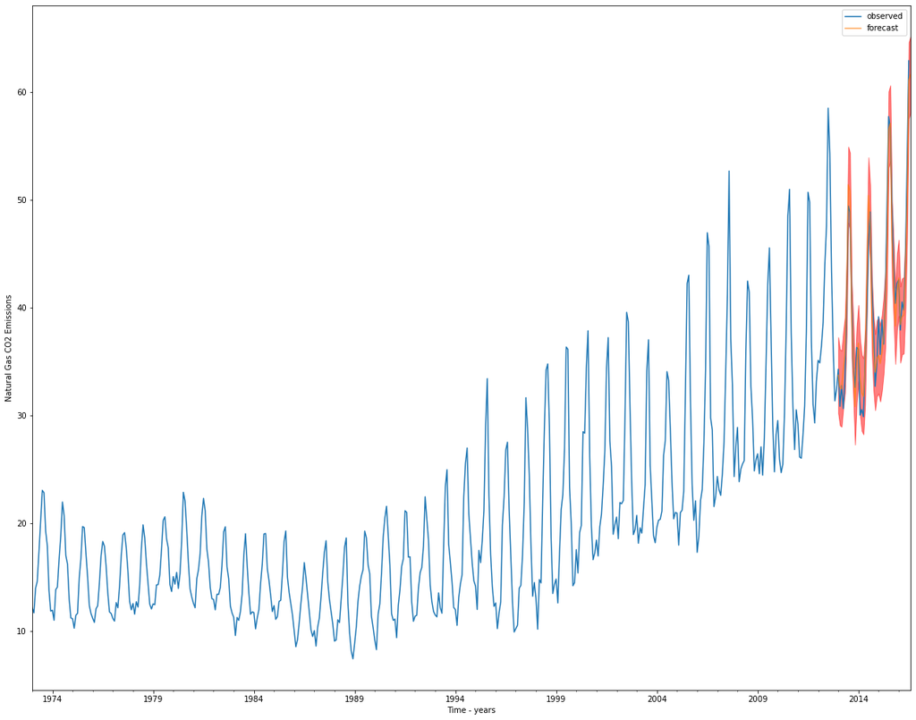

```python
ax = mte['1973':].plot(label='observed')
pred.predicted_mean.plot(ax=ax, label='forecast', alpha=.7)

ax.fill_between(pred_ci.index,
                pred_ci.iloc[:, 0],
                pred_ci.iloc[:, 1], color='r', alpha=.5)

ax.set_xlabel('Time - years')
ax.set_ylabel('Natural Gas CO2 Emissions')
plt.legend()

plt.show()
```

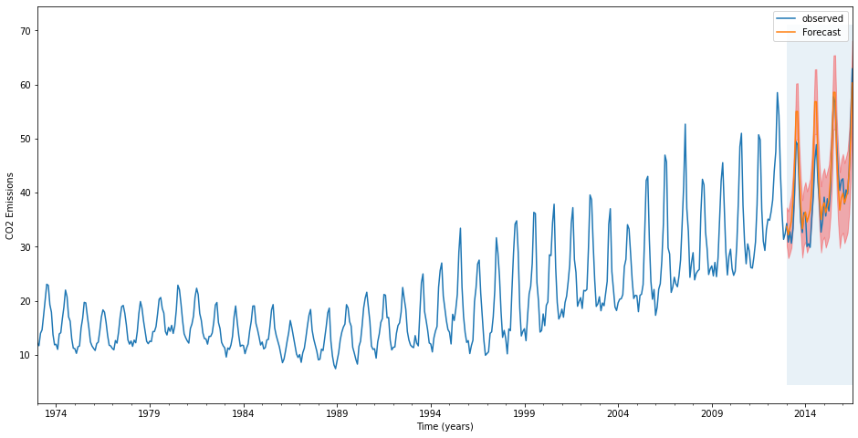

```python
pred_dynamic = results.get_prediction(start=pd.to_datetime('2013-01-31'), dynamic=True, full_results=True)
pred_dynamic_ci = pred_dynamic.conf_int()
ax = mte['1973':].plot(label='observed', figsize=(16, 8))
pred_dynamic.predicted_mean.plot(label='Forecast', ax=ax)

ax.fill_between(pred_dynamic_ci.index,
                pred_dynamic_ci.iloc[:, 0],
                pred_dynamic_ci.iloc[:, 1],
                color='r',
                alpha=.3)

ax.fill_betweenx(ax.get_ylim(),
                 pd.to_datetime('2013-01-31'),
                 mte.index[-1],
                 alpha=.1, zorder=-1)

ax.set_xlabel('Time (years)')
ax.set_ylabel('CO2 Emissions')

plt.legend()
plt.show()
```

#### **Think about it:**

Can we use other forecasting methods such as SARIMA to improve our model performance?

- [A Gentle Introduction to SARIMA for Time Series Forecasting in Python](https://machinelearningmastery.com/sarima-for-time-series-forecasting-in-python/)
- [Forecasting with Seasonal ARIMA in Python](https://www.datasciencecentral.com/profiles/blogs/tutorial-forecasting-with-seasonal-arima)

```python
# Get forecast of 10 years or 120 months steps ahead in future
forecast = results.get_forecast(steps= 120)
# Get confidence intervals of forecasts
forecast_ci = forecast.conf_int()
forecast_ci.head()
```

|  | lower Value | upper Value |
| --- | --- | --- |
| 2016-08-31 | 58.062559 | 65.116049 |
| 2016-09-30 | 47.316614 | 55.987495 |
| 2016-10-31 | 40.736071 | 50.163094 |
| 2016-11-30 | 36.175922 | 46.010287 |
| 2016-12-31 | 38.095110 | 48.172698 |

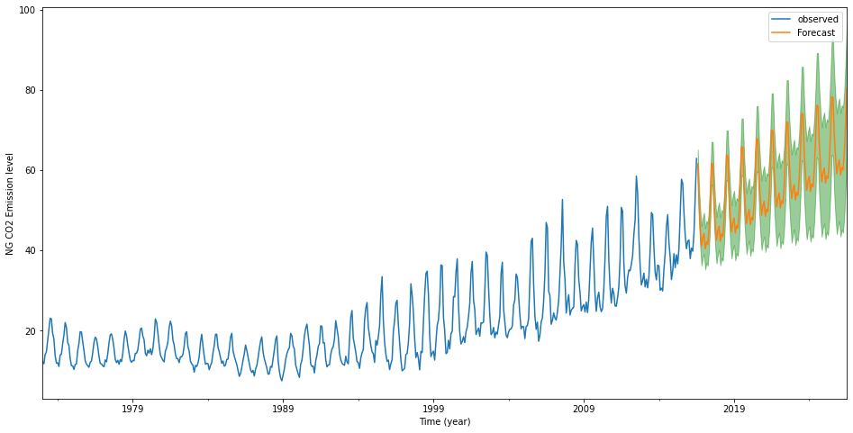

```python
ax = mte.plot(label='observed', figsize=(16, 8))
forecast.predicted_mean.plot(ax=ax, label='Forecast')
ax.fill_between(forecast_ci.index,
                forecast_ci.iloc[:, 0],
                forecast_ci.iloc[:, 1], color='g', alpha=.4)
ax.set_xlabel('Time (year)')
ax.set_ylabel('NG CO2 Emission level')

plt.legend()
plt.show()
```